# The Exponential Distribution in the Land of Asymptopia

Anya Chaliotis

Sep 14, 2015

## Overview

The statistical inference theory states that in the land of Asymptopia everything works out because of the infinite amount of data. Brian Caffo’s lectures demonstrated that all kinds of distributions, from normal to binomial to Poisson, comply with the Law of Large Numbers (LLN) and the Central Limit Theorem (CLT). What about exponential distributions? This report investigate the behavior of the exponential sampling distributions and if they also belong to the land of Asymptopia. We will run simulations with random exponential distributions in R and compare the behavior of statitistics in different sample sizes. Then, we will perform basic inferential data analysis and draw conlusions about usefulness of the theory behind the inferential statistical analysis.

## 1. Simulations

We simulate the exponential distribution in R with rexp(n, lambda) where lambda is the rate parameter. Our lambda = 0.2.

First, we got acquainted with one random exponential distribution of 1000 exponentials:

```r
#the distribution of a large collection of (1000) random exponentials
lambda<-0.2
rexp.size <- 1000
rexp<-rexp(rexp.size, lambda)
```

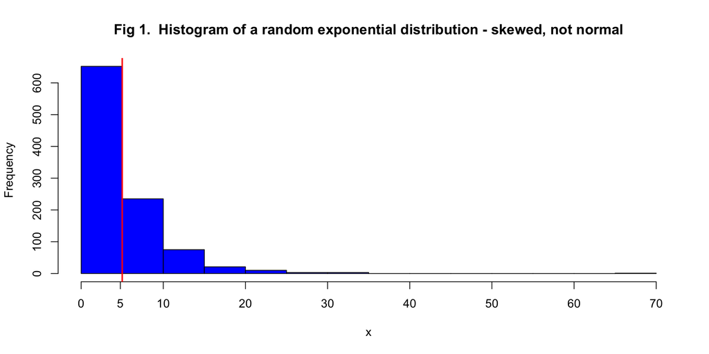

As we suspected, an exponential distribution is not normal. How close is our sample to asymptotic “perfect” characteristics? The red line shows the theoretical mean.  
Theoretical mean = 5 vs. Sample mean = 4.77  
Theoretical variance = 25 vs. Sample variance = 25.81  
Theoretical std dev = 5 vs. our sample std dev = 5.08  
Very close approximations of the population parameters, thanks to the fairly large sample size!

Another way to examine how our sample mean behaves is to look at the sample cumulative means:

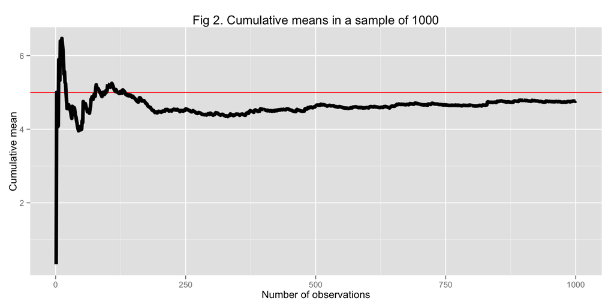

Plotting the cumulative means, we see the LLN in action: our sample mean shows significant variability ealry on, but in a long run, as the sample size grows, the mean gets closer and closer to the theoretical mean (depicted by the red line)!

Since we’re still in the land of Asymptopia, there’s more data for us to play with. One large sample was great, but we can also look at smaller samples and their means. We performed 10, 100, and 1000 simulations of samples, each size 40, and looked at the distribution of their averages:

```r
#the distribution of a large collection of averages of 40 exponentials
sample.size<-40
#define a function that takes in  number of simulations and returns a sampling distribution of means
simulate.rexp.sampling.dist <- function(simulations.num) {
    sampling.dist = NULL
    for (i in 1 : simulations.num) sampling.dist = c(sampling.dist, mean(rexp(sample.size, lambda)))
    sampling.dist
}

dat <-data.frame(
    x=c(simulate.rexp.sampling.dist(10),
        simulate.rexp.sampling.dist(100),
        simulate.rexp.sampling.dist(1000)),
    size = factor(rep(c(10, 100, 1000),times = c(10,100,1000))))
```

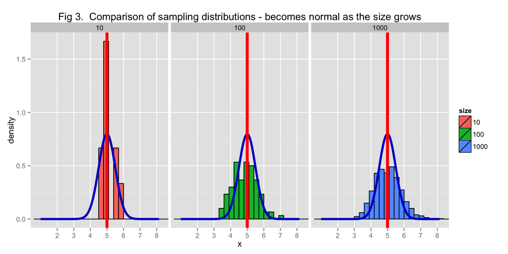

Let’s closer examine cumulative means of our sampling distribution with 1000 simulations:

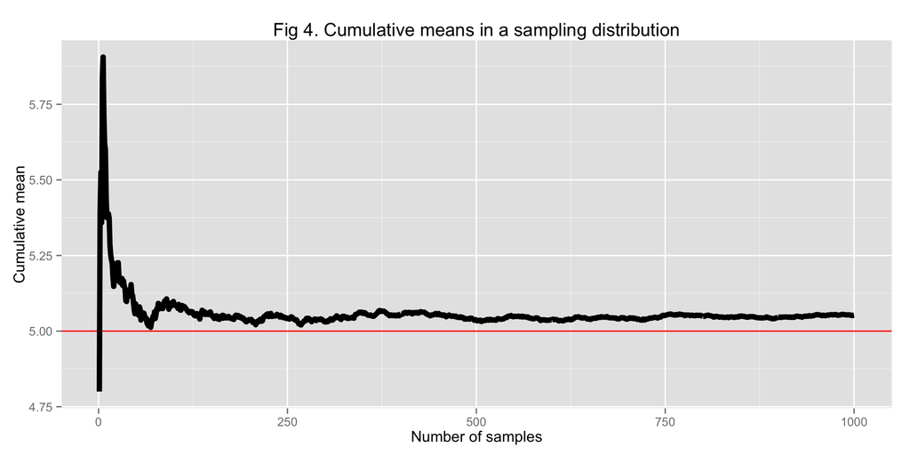

Lastly, we’ll compare the means and std error of 1000 samples, each size 40, to the theoretical characteristics.  
Theoretical mean = 5 vs. Sample mean = 5.05  
Theoretical variance = 0.62 vs. Sample variance = 0.64  
Theoretical std error = 0.79 vs. Sample std error = 0.8

## Conclusion

It was nice to visit the land of Asymptopia, where data is close to infinite and everything works perfectly. With the LLN, we showed that 1 large collection statistics (mean and std dev) got closer and closer to the population parameters as the number of data points increased. With the CLT, we showed, that even with smaller samples, as long as we have many of them, we get to the “perfect” parameters sooner. While the exponential distribution itself is skewed and not normal, the sampling distribution of its means is approximately normal with a sample mean approximating the population mean and a variance given by the standard error of the mean. The CLT is extremely useful in inferential statistics!